# Comparing two groups using the independent two-sample and Paired-sample t-test

## Data Analysis

```python
# Get all race pairs
race_pairs = []

for race1 in range(4):
    for race2  in range(race1+1,5):
        race_pairs.append((races[race1], races[race2]))
3
# Conduct t-test on each pair
for race1, race2 in race_pairs:
    print(race1, race2)
    print(stats.ttest_ind(voter_age[groups[race1]],
                          voter_age[groups[race2]]))
```

```
asian black
Ttest_indResult(statistic=0.838644690974798, pvalue=0.4027281369339345)
asian hispanic
Ttest_indResult(statistic=-0.42594691924932293, pvalue=0.6704669004240726)
asian other
Ttest_indResult(statistic=0.9795284739636, pvalue=0.3298877500095151)
asian white
Ttest_indResult(statistic=-2.318108811252288, pvalue=0.020804701566400217)
black hispanic
Ttest_indResult(statistic=-1.9527839210712925, pvalue=0.05156197171952594)
black other
Ttest_indResult(statistic=0.28025754367057176, pvalue=0.7795770111117659)
black white
Ttest_indResult(statistic=-5.379303881281835, pvalue=1.039421216662395e-07)
hispanic other
Ttest_indResult(statistic=1.5853626170340225, pvalue=0.11396630528484335)
hispanic white
Ttest_indResult(statistic=-3.5160312714115376, pvalue=0.0004641298649066684)
other white
Ttest_indResult(statistic=-3.763809322077872, pvalue=0.00018490576317593065)
```

P-value for white voters is different compared to other races. If using the unadjusted pairwise t-test, we can overestimate the significance. To solve that, we have to divide the statistical significance level by number of comparisons made. The Bonferroni correction is a conservative approach to account for multiple comparisons that may end up rejecting results that in truth are significant.

# Model

Multiple Comparison of Means - Tukey HSD, FWER=0.05

| group1 | group2 | meandiff | p-adj | lower | upper | reject |
| --- | --- | --- | --- | --- | --- | --- |
| asian | black | -0.8032 | 0.9 | -3.4423 | 1.836 | False |
| asian | hispanic | 0.4143 | 0.9 | -2.1011 | 2.9297 | False |
| asian | other | -1.0645 | 0.8852 | -4.2391 | 2.11 | False |
| asian | white | 1.9547 | 0.175 | -0.4575 | 4.3668 | False |
| black | hispanic | 1.2175 | 0.2318 | -0.386 | 2.821 | False |
| black | other | -0.2614 | 0.9 | -2.7757 | 2.253 | False |
| black | white | 2.7579 | 0.001 | 1.3217 | 4.194 | True |
| hispanic | other | -1.4789 | 0.4391 | -3.863 | 0.9053 | False |
| hispanic | white | 1.5404 | 0.004 | 0.3468 | 2.734 | True |
| other | white | 3.0192 | 0.0028 | 0.7443 | 5.2941 | True |

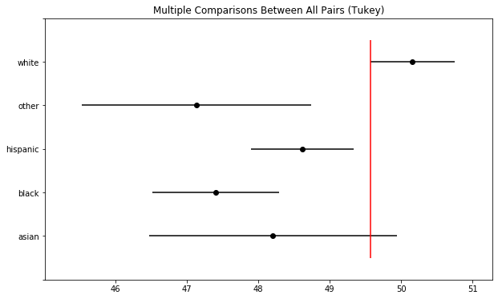

```python
from statsmodels.stats.multicomp import pairwise_tukeyhsd

tukey = pairwise_tukeyhsd(endog=voter_age,     # Data
                          groups=voter_race,   # Groups
                          alpha=0.05)          # Significance level

tukey.plot_simultaneous()    # Plot group confidence intervals
plt.vlines(x=49.57,ymin=-0.5,ymax=4.5, color="red")

tukey.summary()              # See test summary
```

We use Tukey's test because the research was based on different races, and if there were significant differences in means, then Tukey's test would be able to tell us specifically which category had the significant difference. The output shows the average difference, confidence interval, and whether we should or should not reject the null hypothesis for each pair of groups. From the model, it shows that all the pairs that involve white voters, except with asian voters, the null hypothesis should be rejected. Reference:https://www.statisticshowto.datasciencecentral.com/tukey-test-honest-significant-difference/

## Conclusion

The point of the ANOVA test is to be able to compare differences in means between more than one categorical data (in this case, races) to determine whether there is a difference in mean and whether it affected the results. If there wasn't a group that was programmed to show the difference, it would have been hard to tell which category made a difference in results. I think that if there was bigger sample of data, then we are able to better tell if there was a significant difference and reject the null hypothesis.